# Exploring the BRFSS data

## Setup

### Load packages

```r
library(ggplot2)
library(dplyr)
```

### Load data

Make sure your data and R Markdown files are in the same directory. When loaded your data file will be called `brfss2013`. Delete this note when before you submit your work.

```r
load("brfss2013.RData")
```

## Part 1: Data

The dataset is provided by the Behavioral Risk Factor Surveillance System.The dataset contains 491775 observations and 330 variables The BRFSS explained that the data was sampled from randomly selected adults in households. The process of collecting data was conducted through booth landline telephone and cellular telephone. The target samples in the survey are non-institutionalized adult population, aged 18 years or older, who reside in the US.

Except the variable such as identification, the variable types in the dataset could be divided into two main categories— continuous and categorical. Because the data was collected by interviews but not by assignment sampling, the analysis based on the data only offers association but not causality.

## Part 2: Research questions

## Research quesion 1:

**What is the relationship between Average Alcoholic Drinks Per Day In Past 30 and the percentage of people diagnosed heart attack in each state?**

**Variables:**

X_state: States,

avedrnk2: Average Alcoholic Drinks Per Day In Past 30,

cvdinfr4: Ever Diagnosed With Heart Attack.

**Reason:** The analysis will answered whether the relationship is strong positive/negative or no correlation. Although the analysis only provides association but not causality, people will be interested in this question because the analysis offers an important information to further analysis on whether decreasing the alcohol consume can decrease the risk of heart detect.

## Research quesion 2:

**When the sleep time is approximately 8 hours, is there any difference in high blood pressure diagnosed percentage between people who felt nervous most of the time in a month and people who felt nervous a little of the time?**

**Variables:**

bphigh4: Ever Told Blood Pressure High

misnervs: How Often Feel Nervous Past 30 Days

sleptim1: How Much Time Do You Sleep

**Reason:** The analysis will offer information about the relationship between the sleeping time and blood pressure. If the analysis result shows that people experienced longer nervous time have higher percentage with high blood pressure, a further interest to what made this result could be mentioned.

## Research quesion 3:

**Between people with same educational level and same employment status, is a person slept 5 hours has a longer sleeping time than the rest of people in the criteria?**

**Variables:**

sleptim1: How Much Time Do You Sleep

educa: Education Level

employ1: Employment Status

**Reason:**

People may interested in the analysis because this analysis will provide information about the sleep time about one person. People may use information to compare the sleeping time of themselves to other people with a same background. It would be a really important information for people to adjust their sleeping time.

## Part 3: Exploratory data analysis

NOTE: Insert code chunks as needed by clicking on the “Insert a new code chunk” button (green button with orange arrow) above. Make sure that your code is visible in the project you submit. Delete this note when before you submit your work.

**Research quesion 1:**

```r
Q1<- brfss2013%>%
  filter(cvdinfr4== "Yes", avedrnk2<=76)

Q1_state<-Q1%>%
  group_by(X_state) %>%
  summarise(heartattin_state= (count = n()))%>%
  filter(heartattin_state>1)

Q1_total_state<-brfss2013%>%
  group_by(X_state)%>%
  summarise(totalheartattby_state=(count=n()))%>%
  filter(totalheartattby_state>1)

Q1_combinedtable<- merge(Q1_state,Q1_total_state)

Q1_combinedtable<- Q1_combinedtable%>%
  mutate(heartattpercentage= heartattin_state/totalheartattby_state)

Q1_combinedtable%>%
  group_by(X_state)%>%
  arrange(desc(heartattpercentage))
```

```
## # A tibble: 53 x 4
## # Groups:   X_state [53]
##          X_state heartattin_state totalheartattby_state heartattpercentage
##           <fctr>            <int>                 <int>              <dbl>
##  1        Nevada              135                  5101         0.02646540
##  2         Maine              215                  8273         0.02598815
##  3      Michigan              331                 12761         0.02593841
##  4       Florida              830                 33668         0.02465249
##  5       Arizona              104                  4253         0.02445333
##  6  Rhode Island              156                  6531         0.02388608
##  7 New Hampshire              144                  6076         0.02369980
##  8  North Dakota              181                  7806         0.02318729
##  9  Pennsylvania              264                 11429         0.02309913
## 10          Ohio              271                 11971         0.02263804
## # ... with 43 more rows
```

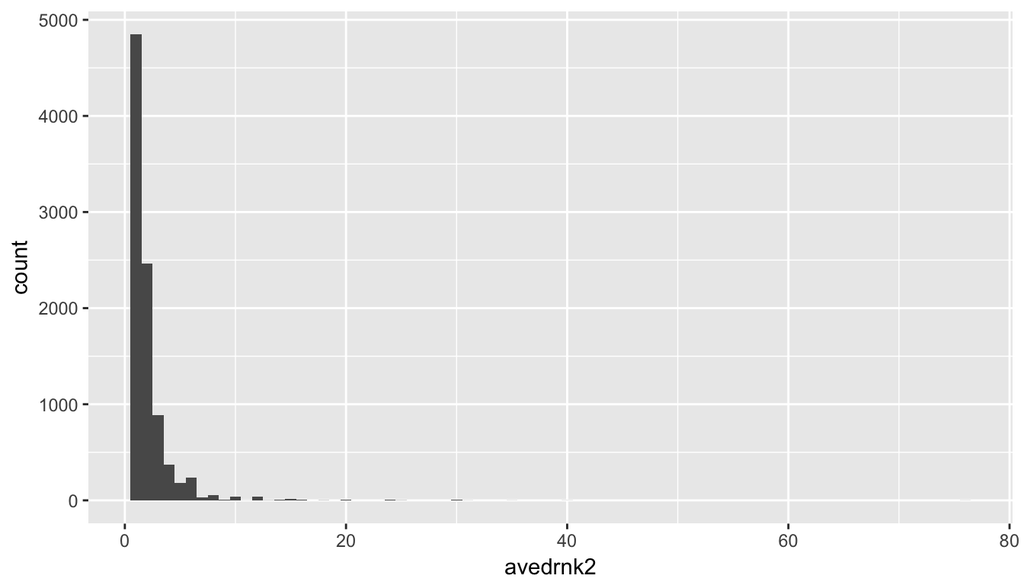

```r
Q1_meandrinking<-Q1%>%
  group_by(X_state)%>%
  summarise(meandrinking_state=mean(avedrnk2))

Q1_combinedtable<-merge(Q1_combinedtable, Q1_meandrinking)

ggplot(data= Q1, aes(x= avedrnk2))+geom_histogram(binwidth = 1)
```

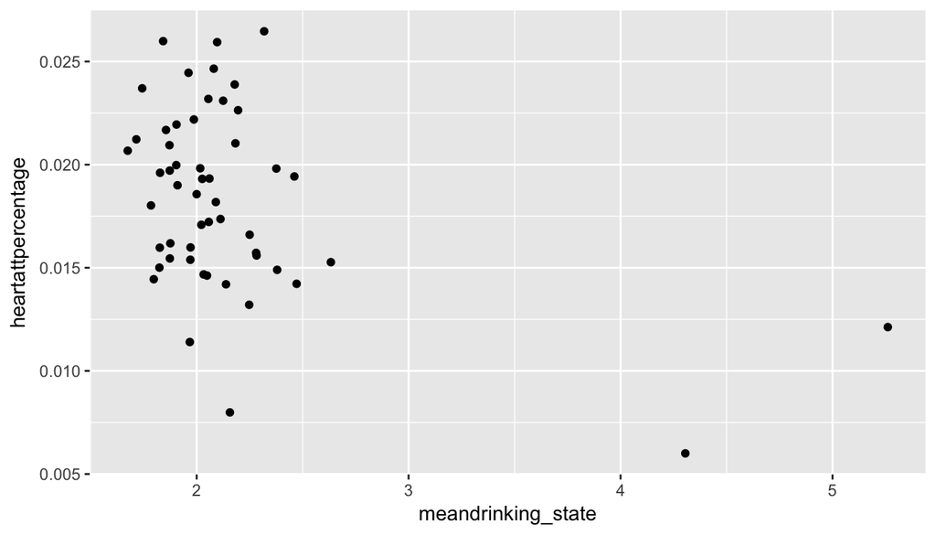

```r
ggplot(data = Q1_combinedtable, aes(x=meandrinking_state,y= heartattpercentage))+geom_point()
```

This point plot showed the relationship between the percentage of heartattack and the meandrinking. The result indicates that there is no strong correlation between these two variables and there are two ourliers in the oberservations. Since the result did not sprovide strong correlation, we may need to switch to other variables to analyze the further about heart attacks.